# Phân tích kết quả của thử nghiệm A/B trong game Cookie Cats

Nhóm 26

10/28/2024

## 1.Bảng tóm tắt, khái quát về dữ liệu.

```r
#Cài đặt các thư viện cần thiết
library(tidyverse)
```

```r
library(readr)
library(ggplot2)
library(janitor)
library(plotly)
library(hrbrthemes)

library(boot)
library(dplyr)
library(ggplot2)
```

```r
cookie_cats <- read_csv('cookie_cats.csv') |> clean_names()
glimpse(cookie_cats)
```

```
## Rows: 90,189
## Columns: 5
## $ userid         <dbl> 116, 337, 377, 483, 488, 540, 1066, 1444, 1574, 1587, 1…
## $ version        <chr> "gate_30", "gate_30", "gate_40", "gate_40", "gate_40", …
## $ sum_gamerounds <dbl> 3, 38, 165, 1, 179, 187, 0, 2, 108, 153, 3, 0, 30, 39, …
## $ retention_1    <lgl> FALSE, TRUE, TRUE, FALSE, TRUE, TRUE, FALSE, FALSE, TRU…
## $ retention_7    <lgl> FALSE, FALSE, FALSE, FALSE, TRUE, TRUE, FALSE, FALSE, T…
```

```r
cookie_cats |> group_by(version) |> summarise(n = n(), mean_sum_gamerounds = mean(sum_gamerounds), sd_sum_gamerounds = sd(sum_gamerounds), retention_1 = mean(retention_1), retention_7 = mean(retention_7))
```

```
## # A tibble: 2 × 6
##   version     n mean_sum_gamerounds sd_sum_gamerounds retention_1 retention_7
##   <chr>   <int>               <dbl>             <dbl>       <dbl>       <dbl>
## 1 gate_30 44700                52.5              257.       0.448       0.190
## 2 gate_40 45489                51.3              103.       0.442       0.182
```

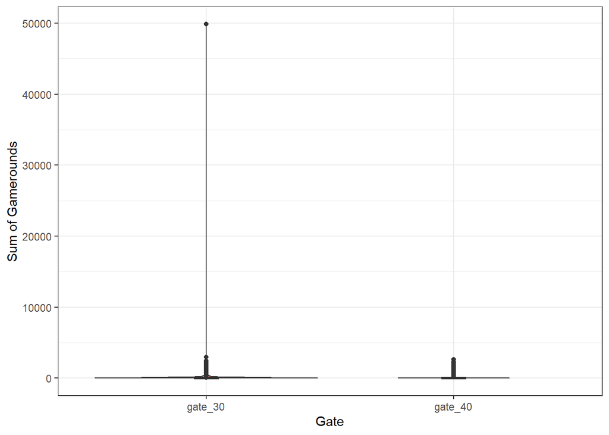

```r
ggplot(cookie_cats, aes(x = version, y = sum_gamerounds, fill = version)) +
  geom_violin() +
  geom_boxplot(width = 0.1) +
  labs(x = "Gate", y = "Sum of Gamerounds") +
  theme_bw() + theme(legend.position = "none")
```

Để thấy rõ hơn sự phân bố của dữ liệu, phóng to vùng (0, 500)

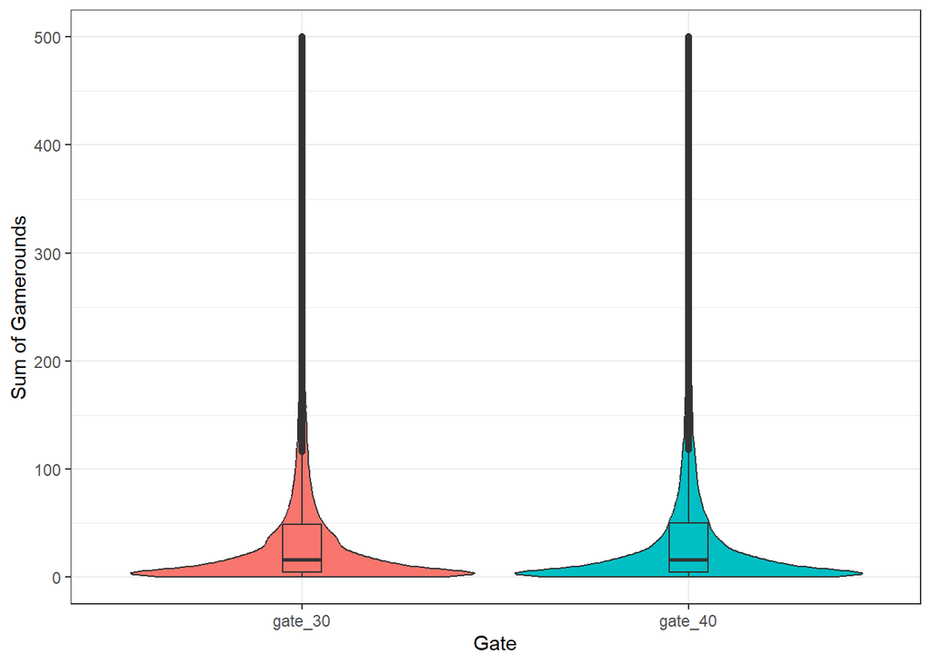

```r
ggplot(cookie_cats, aes(x = version, y = sum_gamerounds, fill = version)) +
  geom_violin() +
  geom_boxplot(width = 0.1) +
  labs(x = "Gate", y = "Sum of Gamerounds") +
  theme_bw() + theme(legend.position = "none") +
  ylim(0, 500)
```

Từ biểu đồ, nhận thấy trung bình của mỗi mẫu giống nhau nên ta sẽ kiểm định 2 phía cho trung bình tổng số vòng chơi với độ tin cậy 95% để rút ra nhận xét sự khác nhau của cổng chơi có ảnh hưởng đến tổng doanh thu hay không.

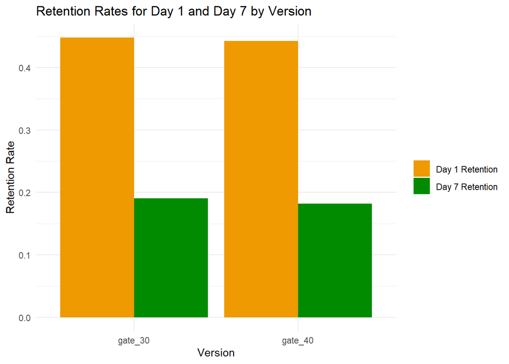

```r
retention_rates <- cookie_cats |>  group_by(version) |>  summarise(
    retention_1_rate = mean(retention_1),
    retention_7_rate = mean(retention_7)) |>
  pivot_longer(cols = starts_with("retention"), names_to = "retention_type", values_to = "rate")

ggplot(retention_rates, aes(x = version, y = rate, fill = retention_type)) +
  geom_col(position = "dodge") +
  theme_minimal() +
  labs(y = "Retention Rate", x = "Version", title = "Retention Rates for Day 1 and Day 7 by Version") +
  scale_fill_manual(values = c("retention_1_rate" = "orange2", "retention_7_rate" = "green4"), labels = c("Day 1 Retention", "Day 7 Retention")) +
  theme(legend.title = element_blank())
```

Các tỷ lệ người chơi quay lại chơi sau 1 ngày và 7 ngày ở hai cổng có sự tương đồng với nhau. Vì vậy, thực hiện kiểm định 2 phía cho tỷ lệ của retention_1 và retention_7 với độ tin cậy 95% để kiểm tra xem sự bắt đầu ở cổng chơi khác nhau có ảnh hưởng đến trải nghiệm của người chơi hay không.

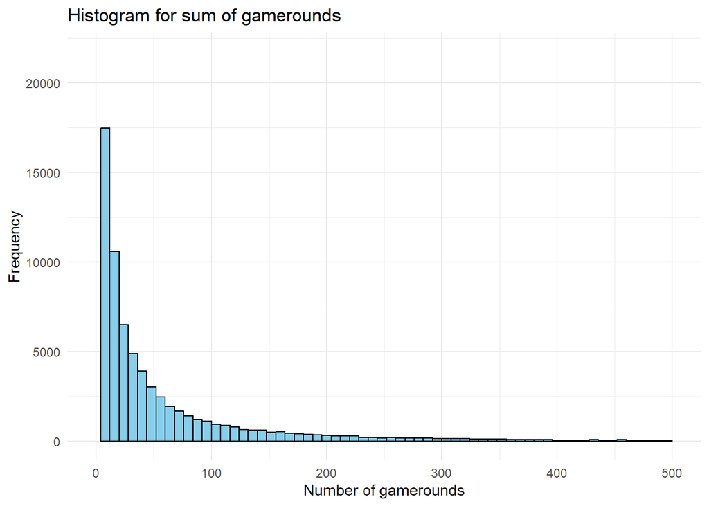

```r
ggplot(cookie_cats, aes(x = sum_gamerounds)) +
  geom_histogram(binwidth = 8, fill = "skyblue", color = "black") +
  labs(title = "Histogram for sum of gamerounds", x = "Number of gamerounds", y = "Frequency") +
  xlim(0, 500) +
  theme_minimal()
```

Biểu đồ histogram cho thấy không có phân phối chuẩn, đồ thị lệch về phía bên phải, tổng số lượng vòng chơi chủ yếu từ khoảng 0-50 vòng chơi.

## 2. Đề ra các phương án xử lý dữ liệu dựa trên các công cụ của A/B testing nhằm đưa ra bằng chứng để trả lời cho câu hỏi “Việc thay đổi cổng băt đầu có thực sự ảnh hưởng tới doanh thu cũng như trải nghiệm của người chơi?”.

Đầu tiên, phân tích “Việc thay đổi cổng băt đầu có thực sự ảnh hưởng tới doanh thu” chúng ta sẽ phân tích trên số lượng vòng chơi (sum_gameround )

Mục tiêu: Xác định liệu việc thay đổi cổng từ cấp 30 lên cấp 40 có ảnh hưởng đến số vòng chơi trung bình của người chơi hay không do số vòng chơi trung bình có thể phản ánh mức độ tham gia của người chơi và tiềm năng doanh thu từ trò chơi.

Phương pháp:

Kiểm tra phân phối của biến sum_gamerounds: Tạo biểu đồ phân phối (histogram ) cho số vòng chơi để xem liệu dữ liệu có tuân theo phân phối chuẩn hay không. Nếu dữ liệu phân phối chuẩn, có thể sử dụng kiểm định t-test. Nếu không phân phối chuẩn, sử dụng kiểm định bootstrap.

So sánh số vòng chơi trung bình giữa hai nhóm:

Sử dụng kiểm định bootstrap để xây dựng phân phối mẫu cho sự khác biệt trung bình giữa hai nhóm. Thực hiện bootstrap với số lần lặp đủ lớn (ví dụ: 1000 lần) để tính p-value và khoảng tin cậy cho sự khác biệt trung bình.

Tiếp theo, phân tích “Việc thay đổi cổng băt đầu có thực sự ảnh hưởng tới trải nghiệm người chơi” dựa trên retetion_1 và retetion_7 .

Phương án kiểm định sự khác biệt về tỷ lệ giữ chân sau 7 ngày: Sử dụng kiểm định hoán vị cho tỷ lệ để so sánh tỷ lệ giữ chân sau 7 ngày giữa hai nhóm. Điều này giúp xác định liệu có sự khác biệt có ý nghĩa thống kê về tỷ lệ giữ chân dài hạn giữa hai nhóm hay không.

Phương án kiểm định sự khác biệt về tỷ lệ giữ chân sau 1 ngày: Sử dụng kiểm định hoán vị cho tỷ lệ để so sánh tỷ lệ giữ chân sau 1 ngày giữa hai nhóm. Điều này giúp xác định liệu có sự khác biệt có ý nghĩa thống kê về tỷ lệ giữ chân dài hạn giữa hai nhóm hay không.

## 3.Hãy cố gắng tận dụng hết các biến được cung cấp, để xử lý dữ liệu theo các phương án đã đề ra.

Kiểm định giả thuyết:

H0: Trung bình số vòng trò chơi mà người chơi đã chơi trong 2 tuần đầu tiên sau khi cài đặt là giống nhau với 2 cổng

```r
bootstrap_permutation_test <- function(x, y, R, alter) {
  # Tách dữ liệu theo nhãn
  data_split <- split(x, y)
  group_A <- data_split[[1]]
  group_B <- data_split[[2]]

  # Tính toán trung bình của hai nhóm
  mean_A <- mean(group_A)
  mean_B <- mean(group_B)

  # Tạo các mẫu bootstrap
  res_bootstrap <- numeric(R)
  for (i in 1:R) {
    sample_A <- sample(group_A, length(group_A), replace = TRUE)
    sample_B <- sample(group_B, length(group_B), replace = TRUE)
    res_bootstrap[i] <- mean(sample_A) - mean(sample_B)
  }

  # Thực hiện hoán vị để tính p-value
  combined_data <- c(group_A, group_B)
  res_permutation <- numeric(R)
  for (i in 1:R) {
    permuted_idx <- sample(1:length(combined_data), length(group_A))
    perm_A <- combined_data[permuted_idx]
    perm_B <- combined_data[-permuted_idx]
    res_permutation[i] <- mean(perm_A) - mean(perm_B)
  }

  # Tính giá trị p-value theo loại kiểm định
  if (alter == "two-sided") {
    p_value <- mean(abs(res_permutation) >= abs(mean_A - mean_B))
  } else if (alter == "left") {
    p_value <- mean(res_permutation <= (mean_A - mean_B))
  } else if (alter == "right") {
    p_value <- mean(res_permutation >= (mean_A - mean_B))
  }

  return(list(
    mean_A = mean_A,
    mean_B = mean_B,
    p_value = p_value
  ))
}
bootstrap_permutation_test(cookie_cats$sum_gamerounds,cookie_cats$version,R=1000,alter='two-sided')
```

```
## $mean_A
## [1] 52.45626
##
## $mean_B
## [1] 51.29878
##
## $p_value
## [1] 0.472
```

Kiểm định permutation test cho tỉ lệ người chơi có quay lại sau 1 ngày cài đặt.

H0: Tỉ lệ người chơi có quay lại và chơi sau 1 ngày cài đặt không bị ảnh hưởng bởi version mà người chơi được đưa vào

H1: Tỉ lệ người chơi có quay lại và chơi sau 1 ngày cài đặt bị ảnh hưởng bởi version mà người chơi được đưa vào

```r
perm_fun_prop <- function(x, nA, nB, R) {
  n <- nA + nB
  prop_diff <- numeric(R)

  for (i in 1:R) {
    # Chọn mẫu ngẫu nhiên cho nhóm A và nhóm B
    idx_a <- sample(x = 1:n, size = nA)
    idx_b <- setdiff(x = 1:n, y = idx_a)

    # Tính tỷ lệ 1 cho mỗi nhóm
    prop_diff[i] <- mean(x[idx_a] == 1) - mean(x[idx_b] == 1)
  }

  return(prop_diff)
}

set.seed(21)
diff_mean_prob <- perm_fun_prop(cookie_cats$retention_1, nA = 44700, nB = 45489, R = 1000)
mean_a <- mean(cookie_cats$retention_1[cookie_cats$version == 'gate_30'])
mean_b <- mean(cookie_cats$retention_1[cookie_cats$version == 'gate_40'])
mean(abs(diff_mean_prob) > abs(mean_a - mean_b) )
```

```
## [1] 0.073
```

p_value=0.073 > 0.05, chưa đủ để bác bỏ H0.

Kiểm định giả thuyết:

H0:Tỉ lệ người chơi có quay lại và chơi sau 7 ngày cài đặt không bị ảnh hưởng bởi version mà người chơi được đưa vào

H1: Tỉ lệ người chơi có quay lại và chơi sau 7 ngày cài đặt bị ảnh hưởng bởi version mà người chơi được đưa vào

```r
perm_fun_prop <- function(x, nA, nB, R) {
  n <- nA + nB
  prop_diff <- numeric(R)

  for (i in 1:R) {
    # Chọn mẫu ngẫu nhiên cho nhóm A và nhóm B
    idx_a <- sample(x = 1:n, size = nA)
    idx_b <- setdiff(x = 1:n, y = idx_a)

    # Tính tỷ lệ 1 cho mỗi nhóm
    prop_diff[i] <- mean(x[idx_a] == 1) - mean(x[idx_b] == 1)
  }

  return(prop_diff)
}

set.seed(21)
diff_mean_prob <- perm_fun_prop(cookie_cats$retention_7, nA = 44700, nB = 45489, R = 1000)
mean_a <- mean(cookie_cats$retention_7[cookie_cats$version == 'gate_30'])
mean_b <- mean(cookie_cats$retention_7[cookie_cats$version == 'gate_40'])
mean(abs(diff_mean_prob) > abs(mean_a - mean_b) )
```

```
## [1] 0.003
```